# Исследование объявлений о продаже квартир

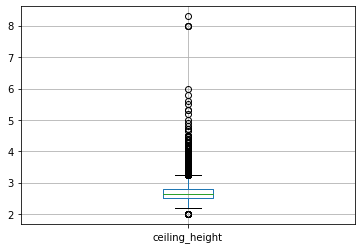

```python
data.query('ceiling_height > 0').boxplot(column='ceiling_height')
```

Гораздо лучше. Думаю, отрежем всё после 4. Посмотрим на этот участок на гистограмме.

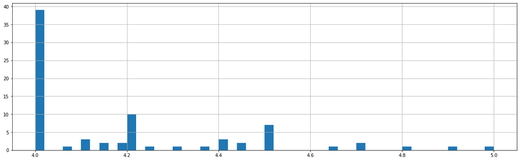

```python
data[data['ceiling_height'] > 0]['ceiling_height'].hist(bins=50, range=(4, 5), figsize=(20, 6))
```

После 4 очень мало, обрезаем. А что по высоте меньше 2,5?

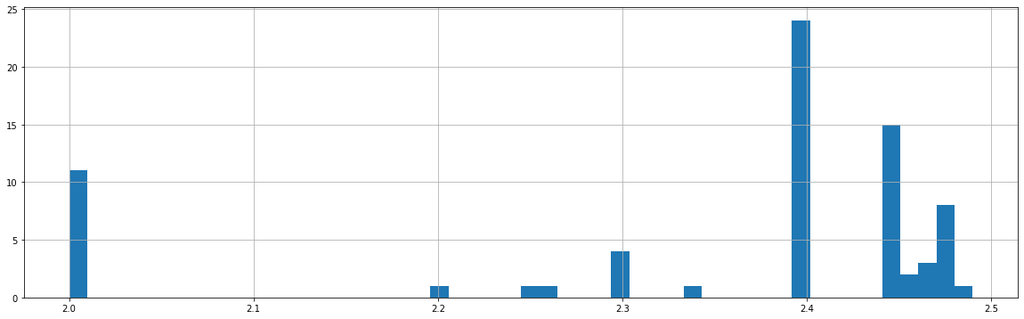

```python
data[data['ceiling_height'] > 0]['ceiling_height'].hist(bins=50, range=(2, 2.49), figsize=(20, 6))
```

Мало, но что-то есть. Оставим. Денис сказал, что меньше 2,4 можно обрезать.

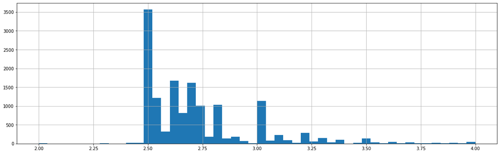

```python
data[data['ceiling_height'] > 0]['ceiling_height'].hist(bins=50, range=(2, 4), figsize=(20, 6))
```

Почти всё в пределах 2,5м-3м. Давайте посчитаем, сколько точно.

```python
data[(data['ceiling_height'] >= 2.5) & (data['ceiling_height'] <= 3)]['ceiling_height'].count()
```

```
12919
```

```python
data[(data['ceiling_height'] > 0) & (data['ceiling_height'] <= 4)]['ceiling_height'].describe()
```

```
count    14447.000000
mean         2.720889
std          0.258094
min          2.000000
25%          2.510000
50%          2.650000
75%          2.800000
max          4.000000
Name: ceiling_height, dtype: float64
```

**Итого.** Средняя высота = 2,72 метра. Медианная 2,65 метра. 90% квартир имеют потолки от 2,5 до 3 метров. Мы обработали аномальные значения и взяли за верхнюю границу высоты 4 метра.

**Тип этажа**

```python
data['floor_type'].value_counts()
```

```
другой        17363
последний      3361
первый         2892
неизвестно       83
Name: floor_type, dtype: int64
```

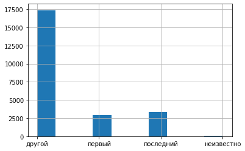

```python
data['floor_type'].hist()
```

**Итого**. 12% первых этажей. 14% последних. 74% других.

**Количество этажей в доме**

```python
data[data['floors_total'] > 0]['floors_total'].describe()
```

```
count    23613.000000
mean        10.673824
std          6.597173
min          1.000000
25%          5.000000
50%          9.000000
75%         16.000000
max         60.000000
Name: floors_total, dtype: float64
```

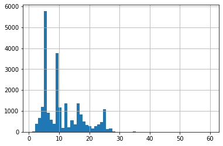

```python
data[data['floors_total'] > 0]['floors_total'].hist(bins=60)
```

Ну, в целом, это похоже на отстойное распределение с поправкой на выбросы, связанные с большим количеством типовых домов.

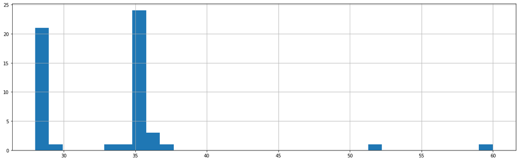

```python
data[data['floors_total'] > 0]['floors_total'].hist(bins=33, range=(28,60), figsize=(20, 6))
```

Обрежем после 27.

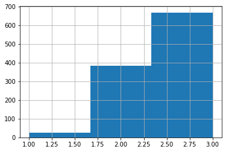

```python
data[data['floors_total'] > 0]['floors_total'].hist(bins=3, range=(1,3))
```

Посмотрим на данные по одноэтажным домам.

```python
data[data['floors_total'] == 1][['last_price','total_area','living_area','kitchen_area','locality_name','centers_range_km']]
```

|  | last_price | total_area | living_area | kitchen_area | locality_name | centers_range_km |
| --- | --- | --- | --- | --- | --- | --- |
| 3076 | 2000000 | 80.0 | 48.5 | 10.0 | Волосово | -0.0 |
| 4379 | 5300000 | 58.5 | 31.6 | 9.4 | поселок Рощино | -0.0 |
| 5300 | 2990000 | 60.0 | 50.0 | 10.0 | поселок станции Вещево | -0.0 |
| 5698 | 450000 | 42.0 | 23.0 | 5.8 | поселок Будогощь | -0.0 |
| 5787 | 9000000 | 88.0 | NaN | NaN | Санкт-Петербург | 21.0 |
| 7962 | 550000 | 46.2 | NaN | NaN | Луга | -0.0 |
| 8335 | 2700000 | 80.0 | 45.0 | 15.0 | Луга | -0.0 |
| 8388 | 3550000 | 48.2 | 33.9 | 9.1 | Сестрорецк | 31.0 |
| 9517 | 1200000 | 39.4 | NaN | NaN | поселок Гаврилово | -0.0 |
| 9752 | 850000 | 62.0 | 31.0 | 11.0 | деревня Сижно | -0.0 |
| 10817 | 790000 | 50.6 | 32.0 | NaN | поселок Ефимовский | -0.0 |
| 11641 | 3685000 | 44.7 | 23.5 | 15.0 | Санкт-Петербург | 15.0 |
| 11746 | 1070000 | 38.8 | 28.1 | 5.5 | деревня Большие Колпаны | -0.0 |
| 14836 | 3900000 | 45.0 | 28.4 | 3.3 | поселок Стрельна | 24.0 |
| 15543 | 3500000 | 54.0 | 24.4 | 7.3 | поселок Большая Ижора | -0.0 |
| 16444 | 990000 | 88.0 | 40.0 | 6.2 | поселок Оредеж | -0.0 |
| 17020 | 3700000 | 100.0 | 35.0 | 22.0 | деревня Каськово | -0.0 |
| 17744 | 2300000 | 50.9 | 30.0 | 7.0 | поселок Суйда | -0.0 |
| 18900 | 1800000 | 65.0 | NaN | NaN | поселок Свирьстрой | -0.0 |
| 19590 | 6150000 | 95.0 | 65.0 | 21.0 | поселок Рощино | -0.0 |
| 21603 | 1900000 | 40.0 | 19.2 | 6.5 | поселок Сосново | -0.0 |
| 22550 | 5800000 | 115.0 | 40.0 | 14.0 | Сестрорецк | 35.0 |
| 22841 | 980000 | 54.0 | NaN | NaN | поселок Пчевжа | -0.0 |
| 22855 | 2950000 | 31.0 | 16.4 | 5.6 | Зеленогорск | 54.0 |
| 23498 | 1600000 | 54.0 | 33.0 | 3.5 | Высоцк | -0.0 |

Ладно, оставим их.

```python
data[(data['floors_total'] > 4) & (data['floors_total'] < 26)]['floors_total'].count()
```

```
20995
```

20995 домов в промежутке между 5 и 25 этажами включительно.

```python
data[(data['floors_total'] > 0) & (data['floors_total'] < 28)]['floors_total'].describe()
```

```
count    23559.000000
mean        10.622692
std          6.511834
min          1.000000
25%          5.000000
50%          9.000000
75%         16.000000
max         27.000000
Name: floors_total, dtype: float64
```

**Итого.** Медианное значение 9 этажей. Минимум 1 этаж. Справедливо, меньше этажей строить смысла мало. Максимум этажей 60, но мы не будем брать в рассчёт всё, что выше 27. 89% домов - от 5 до 25 этажей.

**Расстояние до центра города в метрах**

```python
data[data['centers_range'] > 0]['centers_range'].describe()
```

```
count    18180.000000
mean     14191.277833
std       8608.386210
min        181.000000
25%       9238.000000
50%      13098.500000
75%      16293.000000
max      65968.000000
Name: centers_range, dtype: float64
```

Диаметр Санкт-Петербурга в разных направлениях различается. Если говорить о протяжённости города с севера на юг, то в пределах КАД она составляет около 32 км, а за пределами КАД - 52 км. В направлении с северо-запада на юго-восток протяжённость города составляет около 90 км.

Чёрт, я не знал, что Питер так сильно растянут. Спасибо, гугл. Ой, яндекс, простите, пожалуйста.

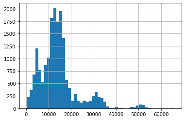

```python
data[data['centers_range'] > 0]['centers_range'].hist(bins=50)
```

Начиная с 20 км объявлений сильно меньше. Почему? Во-первых, кроме как в Питере таких расстояний, вероятно, нет. Нужно ли во-вторых? Давайте посмотрим распределение по Питеру.

```python
data[(data['centers_range'] > 0) & (data['locality_name'] == 'Санкт-Петербург')]['centers_range'].count()
```

```
15701
```

Получается, из других городов только около 2500 объявлений.

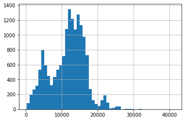

```python
data[(data['centers_range'] > 0) & (data['locality_name'] == 'Санкт-Петербург')]['centers_range'].hist(bins=50)
```

Хмм. Давайте улучшим отображение.

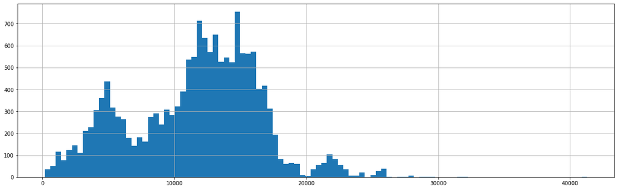

```python
data[(data['centers_range'] > 0) & (data['locality_name'] == 'Санкт-Петербург')]['centers_range'].hist(bins=100, figsize=(20,6))
```

Something's wrong I can feel it. Посмотрим на непитерские объявления.

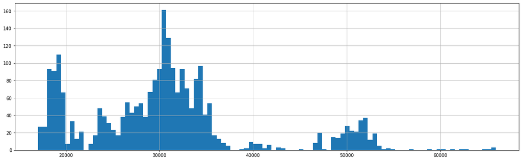

```python
data[(data['centers_range'] > 0) & (data['locality_name'] != 'Санкт-Петербург')]['centers_range'].hist(bins=100, figsize=(20,6))
```

Так, я отказываюсь это понимать. Просто проигнорируем то, что мы сейчас увидели. Забудем как страшный сон. Этого не было, мы сюда не заглядывали.

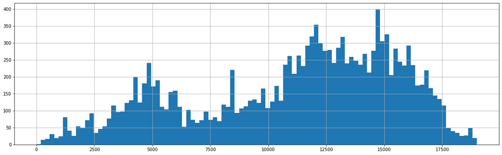

```python
data[(data['centers_range'] > 0) & (data['locality_name'] == 'Санкт-Петербург')]['centers_range'].hist(bins=100, range=(0, 19000), figsize=(20,6))
```

Распределение выглядит не очень, но я думаю, что это связано с тем, что на расстоянии около 15 км в некоторых направлениях город заканчивается. Провал между 5 и 11 км тоже странен, но я не думаю, что нам следует исследовать это. Наверняка тоже какие-то особенности городского планирования, застройки и топографии.

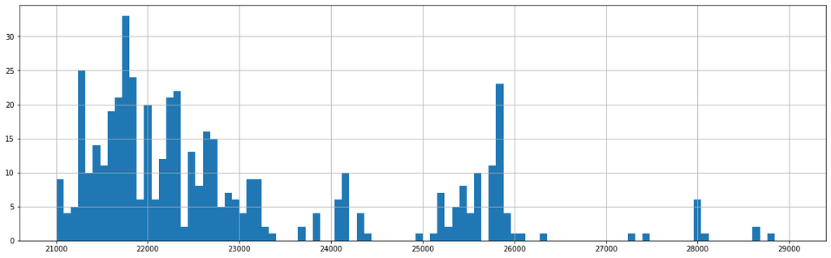

```python
data[(data['centers_range'] > 0) & (data['locality_name'] == 'Санкт-Петербург')]['centers_range'].hist(bins=100, range=(21000, 29000), figsize=(20,6))
```

```python
data[(data['centers_range'] > 0) & (data['centers_range'] < 37000)]['centers_range'].describe()
```

```
count    17863.000000
mean     13563.478531
std       7239.732257
min        181.000000
25%       9098.500000
50%      12995.000000
75%      16109.000000
max      36998.000000
Name: centers_range, dtype: float64
```

Сложно рассматривать этот параметр для всех населённых пунктов сразу. Возможно стоило выкатить 2 анализа: отдельно для Питера и для всех остальных мест. Но это было бы актуально и для всех остальных столбцов. И вообще много как можно было бы разделить анализ по группам данных. Например, Денис сказал, что стоило бы убрать очень дорогие квартиры из общей группы и анализировать их отдельно. В общем, я не буду закапываться в этом всём и просто посчитаю мух вместе с котлетами.

**Итого.** После 37 км квартир почти нет, ограничили потолок этим уровнем. Медианной расстояние 13км. 75% квартир находятся в пределах 16км от центра населённого пункта.

**Расстояние до ближайшего парка**

```python
data[data['parks_nearest'] >= 0]['parks_nearest'].describe()
```

```
count    8075.000000
mean      489.505015
std       337.380019
min         1.000000
25%       288.000000
50%       454.000000
75%       612.000000
max      2984.000000
Name: parks_nearest, dtype: float64
```

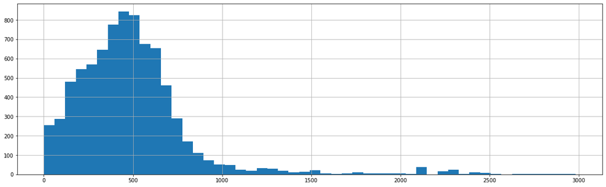

```python
data[data['parks_nearest'] >= 0]['parks_nearest'].hist(bins=50, figsize=(20,6))
```

Рапределение выглядит норм.

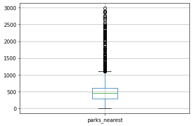

```python
data[data['parks_nearest'] >= 0].boxplot(column='parks_nearest')
```

Отрезаем на 2500м.

```python
data[(data['parks_nearest'] >= 0) & (data['parks_nearest'] < 2500)]['parks_nearest'].describe()
```

```
count    8063.000000
mean      486.126504
std       326.012504
min         1.000000
25%       287.000000
50%       453.000000
75%       611.000000
max      2489.000000
Name: parks_nearest, dtype: float64
```

**Итого.** Данные есть только по 8000 квартир. Мы установили потолок на уровне 2500м. Медианное расстояние 450м. 75% объявлений в пределах 611м.